# Description

emeScheme Version v0.7.1

Rainer M Krug Rainer@uzh.ch

2019-01-25

# Introduction

It aims at providing a structured way to describe the data and to make finding the data using the provided metadata possible.

This scheme **does neither** aim at covering aspects of the actual analysis of the extracted data **nor** does it aim at giving all information to re-run the experiment.

# Terminology and Conventions

## Terminology

- **property set:** a property containing other **property sets** or **data properties**
- **data property:** a property containing only **value properties**. Equivalent to a table.
- **value property:** a column in a **data property**.
- **emeScheme:** the name of this scheme. All properties inherit from the **emeScheme class**
- **emeSchemeSet:** a property set in the emeScheme. It contains the following attributes
  - **propertyName:** the name of the properties contained in this emeSchemeSet
  - **class:** a string defining the class (**emeSchemeSet**, **emeScheme**, plus internal ones)
- **emeSchemeData:** a value property in the emeSAcheme, i.e. a table containing metadata. It contains the following attributes:
  - **propertyName:** the name of the property
  - **names:** the column names of the table
  - **units:** the units used each in the column
  - **type:** the type of each column. Can be **numeric** (== **double**), **integer**, **logical** or **character** (== empty)
  - **allowedValues:** a string of comma separated allowed values. *…* indicates that additional velues are allowed
  - **class:** a string defining the class (**emeSchemeData_PROPERTYNAME**, **emeSchemeData**, **emeScheme**, plus internal ones)

## Conventions

- Properties starting with a **capital letters** are **property sets** or **data properties**.
- Properties starting with a **small letter** are **value properties**.

# Structure of the emeScheme

The **emeScheme** is providing meta data for a single datafile. It is a **property set** (`emeSchemeSet`) which contains of five different sets of **data properties** (`emeSchemeData`) which are tables of metadata.

These five **data properties** are:

1. **Experiment**: General informtion about the experiment. Each dataset can only have one.
2. **Species**: Species used in the experiment. Each dataset can have multiple of these.
3. **Treatment**: Description of the treatment and their differences. Each dataset can have multiple of these.
4. **Measurement**: Measurement methodology and parameter. Each dataset can have multiple of these.
5. **DataExtraction**: Methodology of extraction to extract the data to be analysed from the raw data resulting from the Measurement. Each dataset can have multiple of these.

An special role plays the `DataFile` **data property as it is not part of the actual metadata of a data file. It’;s role will be discussed when discussing the data entering b y using the data sheet.

It is important to note that

1. All **data properties** can obtain multiple rows (i.e. are repeatable) of metadata with the exception of the **Experiment** which can contain only one row of metadata.
2. Many **value properties** have an attribute `allowedValues`. If `...` is included in this attribute, any value can be entered, but, if possible, one should choose a value from the list.

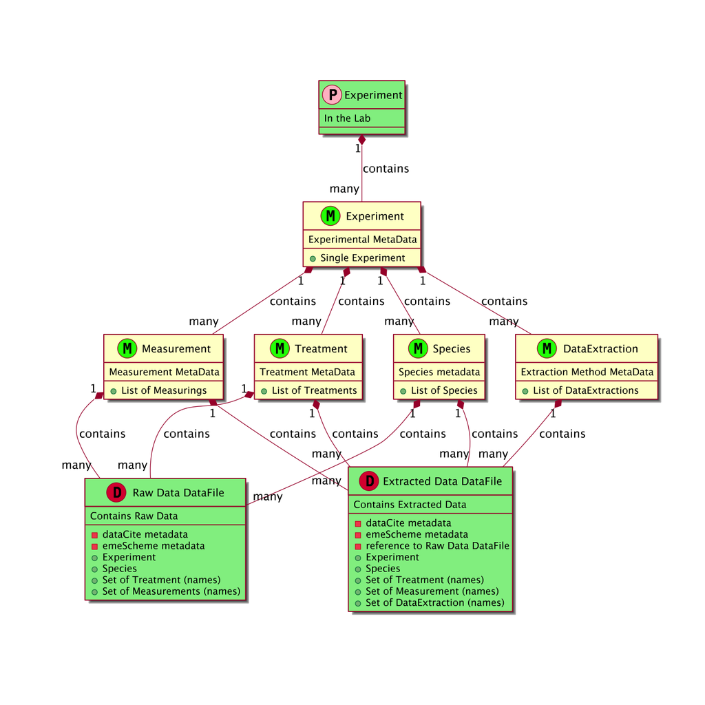

# The emeScheme

This document was than re-ordered and thinned which resulted in the initial verions of [the Google Doc Sheet](https://docs.google.com/spreadsheets/d/1sCImO4VadNwNKuqgtC3CPksS95Tl6SJVtY78aFo9gLg).

Here we describe the structure of the **emeScheme**

## emeScheme Structure

```r
print(emeScheme, printData = F, printAttr = FALSE, printExtAttr = FALSE)
```

```
#>  emeScheme - emeSchemeSet
#>      Experiment - emeSchemeData
#>      Species - emeSchemeData
#>      Treatment - emeSchemeData
#>      Measurement - emeSchemeData
#>      DataExtraction - emeSchemeData
#>      DataFile - emeSchemeData
```

### Experiment

```r
emeScheme_raw$Experiment %>%
  kable() %>%
  kable_styling(bootstrap_options = "striped")
```

| propertySet | valueProperty | unit | type | allowedValues | Description | DATA |
| --- | --- | --- | --- | --- | --- | --- |
| Experiment | name | NA | character | NA | The name of the experiment. | nice experiment |
| NA | temperature | NA | character | treatment, … | Temperature used for all treatments. If different between treatments, use “treatment” and specify in the Treatment sheet. | 22.0 |
| NA | light | NA | character | treatment, … | Light used for all treatments. If different between treatments, use “treatment” and specify in the Treatment sheet. | treatment |
| NA | humidity | NA | character | treatment, … | Humidity used for all treatments. If different between treatments, use “treatment” and specify in the Treatment sheet. | 20.0 |
| NA | incubator | NA | character | none, bench, … | What type of incubator is used. | none |
| NA | container | NA | character | NA | What type of container is used. | bottle |
| NA | microcosmVolume | ml | numeric | NA | Volume of the microcosm container. Not the volume of the culture medium! | 200.0 |
| NA | mediaType | NA | character | NA | NA | xyz |
| NA | mediaConcentration | g/l | numeric | NA | NA | 20.0 |
| NA | cultureConditions | NA | character | axenic, dirty, clean, … | Conditions of the cultures for all treatments. | dirty |
| NA | comunityType | NA | character | treatment, single trophic level, multiple trophic level, … | Characterisation of the cmicrobe community. | single trophic level |
| NA | comment | NA | character | NA | NA | NA |

### Species

```r
emeScheme_raw$Species %>%
  kable() %>%
  kable_styling(bootstrap_options = "striped")
```

| propertySet | Species | ..3 | ..4 | ..5 | ..6 | ..7 |
| --- | --- | --- | --- | --- | --- | --- |
| valueProperty | name | strain | source | density | functionalGroup | comment |
| unit | NA | NA | NA | cells / ml | NA | NA |
| type | character | character | character | numeric | character | character |
| allowedValues | NA | NA | NA | treatment, value | bacteria, bacteriavore, predator, phototroph, … | NA |
| Description | Scientific name of the species. Should only occur once. | NA | Where the species was obtained from. | Initial density used for all treatments. If different between treatments, use “treatment” and specify in the Treatment sheet. | Functional group of the species. | NA |
| DATA | tarantula maximus | green | ebay | 20.0 | bacteria | nice expression of disgust |
| MULTIPLE ROWS | elephantus minimus | blue | amazon | 40.0 | predator | does not like ebay |

### Treatment

```r
emeScheme_raw$Treatment %>%
  kable() %>%
  kable_styling(bootstrap_options = "striped")
```

| propertySet | Treatment | ..3 | ..4 | ..5 | ..6 |
| --- | --- | --- | --- | --- | --- |
| valueProperty | name | parameter | unit | treatmentLevel | comment |
| unit | NA | NA | NA | NA | NA |
| type | character | character | character | character | character |
| allowedValues | NA | temp, light, initial density, comunity composition, densities, dispersal, viscosity, disturbance, communityType, species, …} | C, lux, name, … | value, variable: freetext, … | NA |
| Description | Name of the treatment. Each name specifies one treatment and can (should) occur multiple times. | The parameter decribed in this row. Each parameter should occur only once per name. | The unit of the parameter. | The value of the parameter if the parameter is constant over time, or a description of the variability. | NA |
| DATA | coldlight | temp | C | 20.0 | NA |
| MULTIPLE ROWS | coldlight | light | lux | a lot | NA |
| NA | coldlight | comunity composition | NA | complex | NA |
| NA | hot | temp | C | 35.0 | NA |
| NA | highdens | initial density | ind per ml | 1000.0 | NA |
| NA | coldlight | species | name | tarantula maximus | NA |
| NA | coldlight | species | name | elephantus minimus | NA |
| NA | hot | species | name | tarantula maximus | NA |

### Measurement

```r
emeScheme_raw$Measurement %>%
  kable() %>%
  kable_styling(bootstrap_options = "striped")
```

| propertySet | Measurement | ..3 | ..4 | ..5 | ..6 | ..7 | ..8 | ..9 | ..10 | ..11 |
| --- | --- | --- | --- | --- | --- | --- | --- | --- | --- | --- |
| valueProperty | name | variable | method | unit | object | lengthOfTimeSeries | noOfSamplesInTimeSeries | samplingAverageFrequency | samplingVolume | comment |
| unit | NA | NA | NA | NA | NA | days | NA | days between sampling | ml | NA |
| type | character | character | character | character | character | integer | integer | numeric | numeric | character |
| allowedValues | NA | O2 concentration, video, manual count, … | presens Optode, microscopy, … | %, mmol, count, … | species, OUT, gene, community, particles, … | NA | NA | NA | NA | NA |
| Description | Name of the Measurement process. This includes methodology, variables, … . Each name specifies one Measurement process and can occur multiple times. | The variable measured. | Name of the method used. | Unit of the measured variable | The object measured. E.g. species in the case of manual count, gene for genetic analysis, particle for particle counters. | Total length of the time series in days. | Total number of all samples in the time series. | The average sampling frequency, i.e. noOfSamplesInTimeSeries divided by lengthOfTimeSeries | The sampling volumne. | NA |
| DATA | video_lf | video | microscopy | NA | NA | 50.0 | 25.0 | 2.0 | NA | NA |
| MULTIPLE ROWS | o2_hf | O2 concentration | presens Optode | NA | NA | 50.0 | 50.0 | 1.0 | NA | NA |
| NA | mc | manual count | microscopy | NA | NA | 50.0 | 10.0 | 5.0 | NA | NA |
| NA | os_lf | O2 concentration | presens Optode | NA | NA | 50.0 | 10.0 | 5.0 | NA | NA |
| NA | video_hf | video | microscopy | NA | NA | 50.0 | 100.0 | 0.5 | NA | NA |

### DataExtraction

```r
emeScheme_raw$DataExtraction %>%
  kable() %>%
  kable_styling(bootstrap_options = "striped")
```

| propertySet | DataExtraction | ..3 | ..4 | ..5 | ..6 |
| --- | --- | --- | --- | --- | --- |
| valueProperty | name | method | parameter | value | comment |
| unit | NA | NA | NA | NA | NA |
| type | character | character | character | character | character |
| allowedValues | NA | bemovi x.y.z, … | NA | NA | NA |
| Description | Name of the DataExtraction process. This includes methodology, variables, … . Each name specifies one Measurement process and can occur multiple times in the case of multiple parameters in the analysi… | Method used for the DataExtraction process. If possible including version (in the case of R packages). | parameter in the analysis. Only needs to be specified if it varies from the default. Should we use a format like a = 3; n = 30; minSize = 40 instead of one row per parameter? | value of the parameter Should we use a format like a = 3; n = 30; minSize = 40 instead of one row per parameter? | NA |
| DATA | bemovi_1 | bemovi 1.5.4 | a | 3.0 | NA |
| MULTIPLE ROWS | bemovi_1 | bemovi 1.5.4 | n | 40.0 | NA |
| NA | bemovi_1 | bemovi 1.5.4 | minsize | 40.0 | NA |
| NA | bemovi_2 | bemovi 2.0.0 | a | 3.0 | NA |
| NA | bemovi_2 | bemovi 2.0.0 | n | 40.0 | NA |
| NA | bemovi_2 | bemovi 2.0.0 | minsize | 40.0 | NA |

### DataFile

```r
emeScheme_raw$DataFile %>%
  kable() %>%
  kable_styling(bootstrap_options = "striped")
```

| propertySet | DataFile | ..3 | ..4 | ..5 | ..6 |
| --- | --- | --- | --- | --- | --- |
| valueProperty | dataFileName | treatmentName | measurementName | dataExtractionName | comment |
| unit | NA | NA | NA | NA | NA |
| type | character | character | character | character | character |
| allowedValues | NA | coldlight, hot, highdens | video_lf, o2_hf, mc, os_lf, video_hf | bemovi_1, bemovi_2, raw | NA |
| Description | Name of the data file for which the metaData will be collected. Each data file must occur only once! | Names of alltreatments included in the data file as used in the name column in the Treatment sheet. Multiple names have to be comma separated. | Names of the measurement process used to measure the data in the data file as used in the name column in the Measurement sheet. Usually only one name, but multiple names have to be comma separated. | Names of the DataExtraction process used to extract the data in the data file as used in the name column in the DataExtraction sheet. Usually only one name, but multiple names have to be comma separat… | NA |
| DATA | data1.csv | coldlight, hot | video_lf | bemovi_1 | NA |
| MULTIPLE ROWS | data2.csv | hot | NA | bemovi_2 | NA |
| NA | vid.zip | hot | video_lf | raw | NA |
| NA | vid2.zip | coldlight | video_lf | raw | NA |
| NA | vid3.zip | hot | video_hf | raw | NA |
| NA | vid4.zip | coldlight | video_hf | raw | NA |

A **property set** which contains **data properties** must be seen as tables and must therefore have the same number of entries for each data property.

# Example data

# XSD Grammar